# Results - report January

b s

2023-01-09

# Results: Simulation A

## Simulation design

In study A, only fixed slopes and random and fixed intercepts were simulated and analysed.

Study A followed a 4 × 2 × 3 × 4 × 3 factorial design (yielding 288 simulation conditions in total):

- 4 missingness patterns:
  - data missing completely at random *(mcar)*
  - data missing in blocks of consecutive observations *(block)*
  - lowest (100%-compliance) observations set as missing
  - highest and lowest (100%-compliance)/2 observations set as missing
- 2 values of N (number of participants): 20, 100
- 3 values of T.obs (number of datapoints per participant): 20, 50, 100
- 4 values of compliance: 0.4, 0.6, 0.8, 1
- 3 values of real (simulated) fixed autoregressive effect: 0.3, 0.5, 0.7

As focal simulation outcomes, we evaluated the precision, power and standard error of the fixed autoregressive effect estimates. Additionally, we assessed the proportion of models that successfully converged, and the bias in person-mean estimation (i.e., the difference between the real and observed person-mean).

## Outcome: Estimation precision

First, we conducted an ANOVA to assess which of the 5 manipulated factors have an effect on the estimation bias and whether there is an interaction between these effects. Given the large sample size and the fact that we were not testing any a priori hypotheses, we did not use p-values or significance thresholds for statistical inferences; instead, we used the effect size of 0.06 as a cut-off for partial omega squared of each of the effects.

The dataset used for this analysis has 288,000 observations (1,000 observations for each of the 288 simulation conditions).

```r
library(effectsize)
library(ggplot2)
library(tidyverse)

rdslist = list.files(path = here::here("results", "sim_a_norandomslopes"), pattern='*.rds') # put all the data files with results in a list


anova_bias_df = data.frame(matrix(ncol = 7))
colnames(anova_bias_df) = c("B1_bias", "B1_sim", "N", "T.obs", "miss_type", "compliance", "model_observations")

for (i in 1:length(rdslist)){ # for-loop that connects all files from rdslist into one file
  res = readRDS(here::here("results", "sim_a_norandomslopes", rdslist[i]))
  B1_bias = res$beta.hat.lme.list[, 2] - res$b10
  B1_sim = res$b10
  N = res$N
  T.obs = res$T.obs
  miss_type = res$missing_type
  compliance = res$comp_mean
  model_observations = res$model_observations
  results = data.frame(B1_bias, B1_sim, N, T.obs, miss_type, compliance, model_observations)

  anova_bias_df = rbind(anova_bias_df, results)
}

# for some reason, the first row is only NAs, remove it:
anova_bias_df = anova_bias_df[-1, ]
```

### Estimation precision ANOVA results

```r
anova_bias = aov(formula = B1_bias ~ N * T.obs * miss_type * compliance * B1_sim,
                 data = anova_bias_df)

(anova_bias_results = summary(anova_bias))
```

```
##                                         Df Sum Sq Mean Sq   F value   Pr(>F)
## N                                        1    0.1     0.1 3.663e+01 1.43e-09
## T.obs                                    1  354.9   354.9 1.146e+05  < 2e-16
## miss_type                                3 2657.1   885.7 2.859e+05  < 2e-16
## compliance                               1 1707.0  1707.0 5.510e+05  < 2e-16
## B1_sim                                   1  169.0   169.0 5.455e+04  < 2e-16
## N:T.obs                                  1    0.0     0.0 4.950e+00  0.02609
## N:miss_type                              3    0.0     0.0 3.440e-01  0.79369
## T.obs:miss_type                          3   14.1     4.7 1.518e+03  < 2e-16
## N:compliance                             1    0.0     0.0 9.113e+00  0.00254
## T.obs:compliance                         1   22.8    22.8 7.352e+03  < 2e-16
## miss_type:compliance                     3 1157.7   385.9 1.246e+05  < 2e-16
## N:B1_sim                                 1    0.0     0.0 9.464e+00  0.00210
## T.obs:B1_sim                             1    1.8     1.8 5.662e+02  < 2e-16
## miss_type:B1_sim                         3  148.4    49.5 1.597e+04  < 2e-16
## compliance:B1_sim                        1   59.3    59.3 1.914e+04  < 2e-16
## N:T.obs:miss_type                        3    0.0     0.0 3.881e+00  0.00871
## N:T.obs:compliance                       1    0.0     0.0 2.160e-01  0.64248
## N:miss_type:compliance                   3    0.0     0.0 1.300e-01  0.94253
## T.obs:miss_type:compliance               3    8.0     2.7 8.654e+02  < 2e-16
## N:T.obs:B1_sim                           1    0.0     0.0 1.665e+00  0.19689
## N:miss_type:B1_sim                       3    0.0     0.0 5.610e-01  0.64058
## T.obs:miss_type:B1_sim                   3    4.0     1.3 4.351e+02  < 2e-16
## N:compliance:B1_sim                      1    0.0     0.0 2.591e+00  0.10751
## T.obs:compliance:B1_sim                  1    0.4     0.4 1.324e+02  < 2e-16
## miss_type:compliance:B1_sim              3   96.7    32.2 1.040e+04  < 2e-16
## N:T.obs:miss_type:compliance             3    0.0     0.0 4.329e+00  0.00467
## N:T.obs:miss_type:B1_sim                 3    0.0     0.0 3.140e-01  0.81528
## N:T.obs:compliance:B1_sim                1    0.0     0.0 1.053e+00  0.30489
## N:miss_type:compliance:B1_sim            3    0.0     0.0 6.130e-01  0.60655
## T.obs:miss_type:compliance:B1_sim        3    3.2     1.1 3.454e+02  < 2e-16
## N:T.obs:miss_type:compliance:B1_sim      3    0.0     0.0 2.680e-01  0.84885
## Residuals                           287936  892.0     0.0
##
## N                                   ***
## T.obs                               ***
## miss_type                           ***
## compliance                          ***
## B1_sim                              ***
## N:T.obs                             *
```

[output cut: 13 more lines]

```
## N:T.obs:B1_sim
## N:miss_type:B1_sim
## T.obs:miss_type:B1_sim              ***
## N:compliance:B1_sim
## T.obs:compliance:B1_sim             ***
## miss_type:compliance:B1_sim         ***
## N:T.obs:miss_type:compliance        **
## N:T.obs:miss_type:B1_sim
## N:T.obs:compliance:B1_sim
## N:miss_type:compliance:B1_sim
## T.obs:miss_type:compliance:B1_sim   ***
## N:T.obs:miss_type:compliance:B1_sim
## Residuals
## ---
## Signif. codes:  0 '***' 0.001 '**' 0.01 '*' 0.05 '.' 0.1 ' ' 1
```

### Estimation precision ANOVA effect sizes

```r
omega_squared(anova_bias, partial = TRUE)
```

| Parameter | Omega2_partial | CI | CI_low | CI_high |
| --- | --- | --- | --- | --- |
| N | 0.0001237 | 0.95 | 0.0000649 | 1 |
| T.obs | 0.2846006 | 0.95 | 0.3043975 | 1 |
| miss_type | 0.7486321 | 0.95 | 0.7661396 | 1 |
| compliance | 0.6567467 | 0.95 | 0.6779004 | 1 |
| B1_sim | 0.1592520 | 0.95 | 0.1724313 | 1 |
| N:T.obs | 0.0000137 | 0.95 | 0.0000001 | 1 |
| N:miss_type | 0.0000000 | 0.95 | 0.0000000 | 1 |
| T.obs:miss_type | 0.0155581 | 0.95 | 0.0148102 | 1 |
| N:compliance | 0.0000282 | 0.95 | 0.0000050 | 1 |
| T.obs:compliance | 0.0248906 | 0.95 | 0.0239615 | 1 |
| miss_type:compliance | 0.5647679 | 0.95 | 0.5880344 | 1 |
| N:B1_sim | 0.0000294 | 0.95 | 0.0000055 | 1 |
| T.obs:B1_sim | 0.0019586 | 0.95 | 0.0016972 | 1 |
| miss_type:B1_sim | 0.1425901 | 0.95 | 0.1546441 | 1 |
| compliance:B1_sim | 0.0622998 | 0.95 | 0.0681054 | 1 |
| N:T.obs:miss_type | 0.0000300 | 0.95 | 0.0000011 | 1 |
| N:T.obs:compliance | 0.0000000 | 0.95 | 0.0000000 | 1 |
| N:miss_type:compliance | 0.0000000 | 0.95 | 0.0000000 | 1 |
| T.obs:miss_type:compliance | 0.0089240 | 0.95 | 0.0083535 | 1 |
| N:T.obs:B1_sim | 0.0000023 | 0.95 | 0.0000000 | 1 |
| N:miss_type:B1_sim | 0.0000000 | 0.95 | 0.0000000 | 1 |
| T.obs:miss_type:B1_sim | 0.0045019 | 0.95 | 0.0040953 | 1 |
| N:compliance:B1_sim | 0.0000055 | 0.95 | 0.0000000 | 1 |
| T.obs:compliance:B1_sim | 0.0004560 | 0.95 | 0.0003345 | 1 |
| miss_type:compliance:B1_sim | 0.0977698 | 0.95 | 0.1065054 | 1 |
| N:T.obs:miss_type:compliance | 0.0000347 | 0.95 | 0.0000031 | 1 |
| N:T.obs:miss_type:B1_sim | 0.0000000 | 0.95 | 0.0000000 | 1 |
| N:T.obs:compliance:B1_sim | 0.0000002 | 0.95 | 0.0000000 | 1 |
| N:miss_type:compliance:B1_sim | 0.0000000 | 0.95 | 0.0000000 | 1 |
| T.obs:miss_type:compliance:B1_sim | 0.0035750 | 0.95 | 0.0032125 | 1 |
| N:T.obs:miss_type:compliance:B1_sim | 0.0000000 | 0.95 | 0.0000000 | 1 |

The only manipulated parameter that seems to not influence estimation precision is the number of participants. Meanwhile missingness type, compliance, number of observations per participant and the true fixed AR effect value all appear to have an influence on the estimation precision.

*note: I use causal language here (“have an influence on”) - is that a correct thing to do (given that the simulation is basically an experiment), or should I stay with “is associated with”?*

### Estimation precision: mean comparison

#### Missingness type

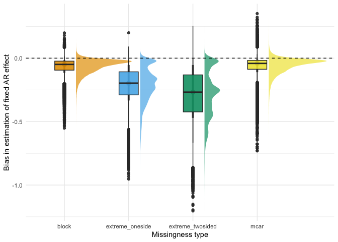

```r
library(ggdist)
# set a colorblind-friendly color pallete
cbPalette = c("#E69F00", "#56B4E9", "#009E73", "#F0E442", "#0072B2", "#D55E00", "#CC79A7", "#000000")

cbPalette_other = c("#0072B2", "#D55E00", "#CC79A7", "#000000")



(boxplot_precision_type = anova_bias_df %>%
  ggplot(aes(x = as.factor(miss_type), y = B1_bias, fill = as.factor(miss_type), group = as.factor(miss_type))) +
  stat_halfeye(justification = -0.2, alpha = 0.7, outlier.size = 1) +
  geom_boxplot(width = 0.3, alpha = 0.9) +
  theme_minimal() +
  scale_fill_manual(values = cbPalette) +
  ylab("Bias in estimation of fixed AR effect") +
  xlab("Missingness type") +
  theme(legend.position = "none") +
  geom_hline(yintercept = 0, linetype = "dashed")
  )
```

Why are the distributions kind-of normal for block and mcar, but tri-modal in the ‘extreme’ conditions? In my opinion, it’s because the bias is (more) dependent on the true effect size in the extreme conditions (the bigger the true AR, the bigger the bias), which causes 3 different values of bias (because we simulated 3 values of true AR)

#### Compliance

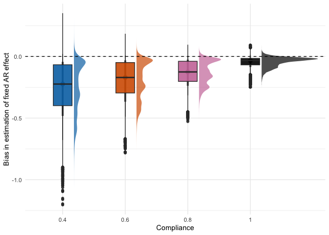

```r
(boxplot_precision_compliance = anova_bias_df %>%
  ggplot(aes(x = as.factor(compliance), y = B1_bias, fill = as.factor(compliance), group = as.factor(compliance))) +
  stat_halfeye(justification = -0.2, alpha = 0.7, outlier.size = 1) +
  geom_boxplot(width = 0.3, alpha = 0.9) +
  theme_minimal() +
  scale_fill_manual(values = cbPalette_other) +
  ylab("Bias in estimation of fixed AR effect") +
  xlab("Compliance") +
  theme(legend.position = "none") +
  geom_hline(yintercept = 0, linetype = "dashed")
  )
```

#### Number of timepoints per participant

The effect of the number of timepoints per participant on estimation bias (averaged over the other manipulated parameters)

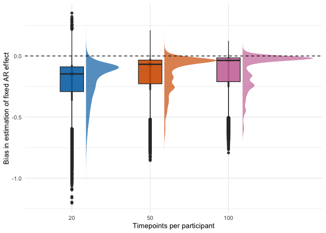

```r
(boxplot_precision_t = anova_bias_df %>%
  ggplot(aes(x = as.factor(T.obs), y = B1_bias, fill = as.factor(T.obs), group = as.factor(T.obs))) +
  stat_halfeye(justification = -0.2, alpha = 0.7, outlier.size = 1) +
  geom_boxplot(width = 0.3, alpha = 0.9) +
  theme_minimal() +
  scale_fill_manual(values = cbPalette_other) +
  ylab("Bias in estimation of fixed AR effect") +
  xlab("Timepoints per participant") +
  geom_hline(yintercept = 0, linetype = "dashed") +
  theme(legend.position = "none")
  )
```

#### Real fixed AR effect

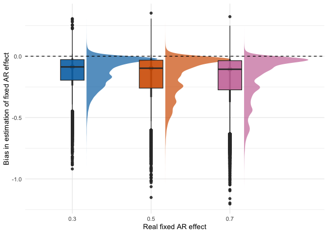

```r
(boxplot_precision_ar = anova_bias_df %>%
  ggplot(aes(x = as.factor(B1_sim), y = B1_bias, fill = as.factor(B1_sim), group = as.factor(B1_sim))) +
  stat_halfeye(justification = -0.2, alpha = 0.7, outlier.size = 1) +
  geom_boxplot(width = 0.3, alpha = 0.9) +
  theme_minimal() +
  scale_fill_manual(values = cbPalette_other) +
  ylab("Bias in estimation of fixed AR effect") +
  xlab("Real fixed AR effect") +
  geom_hline(yintercept = 0, linetype = "dashed") +
  theme(legend.position = "none")
  )
```

### Interactions

#### Number of timepoints per participant * Missingness type

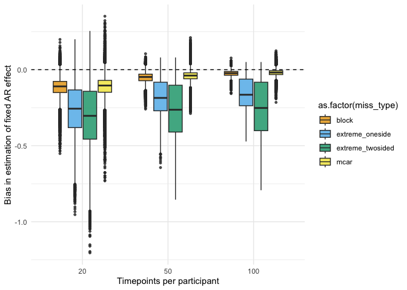

```r
(boxplot_precision_t_misstype = anova_bias_df %>%
  ggplot(aes(x = as.factor(T.obs), y = B1_bias, fill = as.factor(miss_type))) +
  geom_boxplot(width = 0.7, alpha = 0.8, outlier.size = 1) +
  theme_minimal() +
  scale_fill_manual(values = cbPalette) +
  ylab("Bias in estimation of fixed AR effect") +
  xlab("Timepoints per participant") +
  geom_hline(yintercept = 0, linetype = "dashed"))
```

#### Missingness type * True fixed AR effect

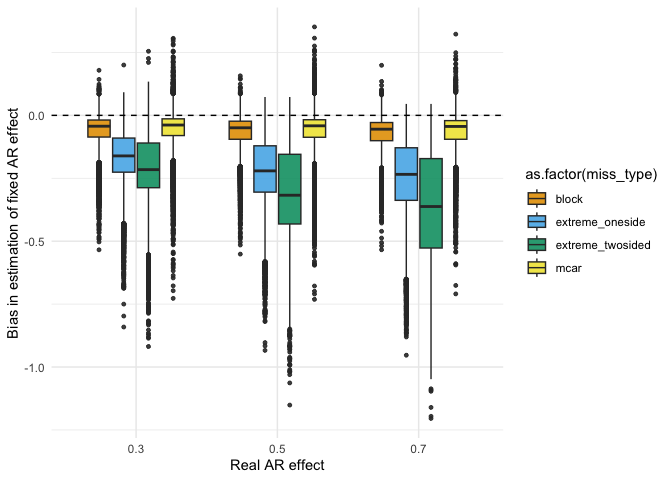

```r
(boxplot_precision_ar_misstype = anova_bias_df %>%
  ggplot(aes(x = as.factor(B1_sim), y = B1_bias, fill = as.factor(miss_type))) +
  geom_boxplot(width = 0.7, alpha = 0.9, outlier.size = 1) +
  theme_minimal() +
  scale_fill_manual(values = cbPalette) +
  ylab("Bias in estimation of fixed AR effect") +
  xlab("Real AR effect") +
  geom_hline(yintercept = 0, linetype = "dashed")
  )
```

#### Compliance * True fixed AR effect

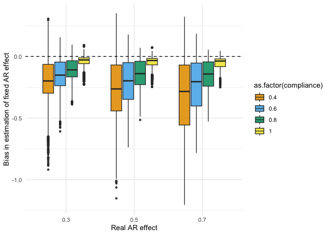

```r
(boxplot_precision_ar_compliance = anova_bias_df %>%
  ggplot(aes(x = as.factor(B1_sim), y = B1_bias, fill = as.factor(compliance)))) +
  geom_boxplot(width = 0.7, alpha = 0.9, outlier.size = 1) +
  theme_minimal() +
  scale_fill_manual(values = cbPalette) +
  ylab("Bias in estimation of fixed AR effect") +
  xlab("Real AR effect") +
  geom_hline(yintercept = 0, linetype = "dashed")
```

#### Compliance * Missingness type

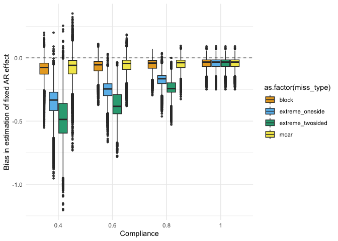

```r
(boxplot_precision_compliance_misstype = anova_bias_df %>%
  ggplot(aes(x = as.factor(compliance), y = B1_bias, fill = as.factor(miss_type))) +
  geom_boxplot(width = 0.7, alpha = 0.9, outlier.size = 1) +
  theme_minimal() +
  scale_fill_manual(values = cbPalette) +
  ylab("Bias in estimation of fixed AR effect") +
  xlab("Compliance") +
  geom_hline(yintercept = 0, linetype = "dashed"))
```

## Outcome: MSE

### MSE ANOVA

```r
anova_mse = aov(formula = B1_se ~ N * T.obs * miss_type * comp_mean * B1_sim,
                 data = overall_df)

(anova_mse_results = summary(anova_mse))
```

```
##                                     Df  Sum Sq Mean Sq F value   Pr(>F)
## N                                    1 0.06043 0.06043 609.183  < 2e-16 ***
## T.obs                                1 0.05997 0.05997 604.542  < 2e-16 ***
## miss_type                            3 0.00409 0.00136  13.730 2.98e-08 ***
## comp_mean                            1 0.05374 0.05374 541.706  < 2e-16 ***
## B1_sim                               1 0.00210 0.00210  21.164 7.05e-06 ***
## N:T.obs                              1 0.00888 0.00888  89.462  < 2e-16 ***
## N:miss_type                          3 0.00062 0.00021   2.076    0.104
## T.obs:miss_type                      3 0.00043 0.00014   1.441    0.232
## N:comp_mean                          1 0.00800 0.00800  80.669  < 2e-16 ***
## T.obs:comp_mean                      1 0.01101 0.01101 111.011  < 2e-16 ***
## miss_type:comp_mean                  3 0.00386 0.00129  12.955 7.79e-08 ***
## N:B1_sim                             1 0.00030 0.00030   3.051    0.082 .
## T.obs:B1_sim                         1 0.00013 0.00013   1.332    0.250
## miss_type:B1_sim                     3 0.00006 0.00002   0.197    0.899
## comp_mean:B1_sim                     1 0.00015 0.00015   1.512    0.220
## N:T.obs:miss_type                    3 0.00007 0.00002   0.237    0.871
## N:T.obs:comp_mean                    1 0.00167 0.00167  16.853 5.66e-05 ***
## N:miss_type:comp_mean                3 0.00059 0.00020   1.987    0.117
## T.obs:miss_type:comp_mean            3 0.00055 0.00018   1.845    0.140
## N:T.obs:B1_sim                       1 0.00002 0.00002   0.187    0.666
## N:miss_type:B1_sim                   3 0.00001 0.00000   0.027    0.994
## T.obs:miss_type:B1_sim               3 0.00000 0.00000   0.005    1.000
## N:comp_mean:B1_sim                   1 0.00002 0.00002   0.215    0.643
## T.obs:comp_mean:B1_sim               1 0.00002 0.00002   0.170    0.680
## miss_type:comp_mean:B1_sim           3 0.00003 0.00001   0.086    0.967
## N:T.obs:miss_type:comp_mean          3 0.00009 0.00003   0.308    0.820
## N:T.obs:miss_type:B1_sim             3 0.00000 0.00000   0.001    1.000
## N:T.obs:comp_mean:B1_sim             1 0.00000 0.00000   0.023    0.879
## N:miss_type:comp_mean:B1_sim         3 0.00000 0.00000   0.012    0.998
## T.obs:miss_type:comp_mean:B1_sim     3 0.00000 0.00000   0.005    0.999
## N:T.obs:miss_type:comp_mean:B1_sim   3 0.00000 0.00000   0.001    1.000
## Residuals                          224 0.02222 0.00010
## ---
## Signif. codes:  0 '***' 0.001 '**' 0.01 '*' 0.05 '.' 0.1 ' ' 1
```

### MSE ANOVA effect sizes

```r
omega_squared(anova_mse, partial = TRUE)
```

| Parameter | Omega2_partial | CI | CI_low | CI_high |
| --- | --- | --- | --- | --- |
| N | 0.6786371 | 0.95 | 0.6262718 | 1 |
| T.obs | 0.6769642 | 0.95 | 0.6243698 | 1 |
| miss_type | 0.1170800 | 0.95 | 0.0522613 | 1 |
| comp_mean | 0.6524701 | 0.95 | 0.5965997 | 1 |
| B1_sim | 0.0654333 | 0.95 | 0.0227297 | 1 |
| N:T.obs | 0.2349835 | 0.95 | 0.1594974 | 1 |
| N:miss_type | 0.0110828 | 0.95 | 0.0000000 | 1 |
| T.obs:miss_type | 0.0045716 | 0.95 | 0.0000000 | 1 |
| N:comp_mean | 0.2166866 | 0.95 | 0.1428046 | 1 |
| T.obs:comp_mean | 0.2764011 | 0.95 | 0.1983959 | 1 |
| miss_type:comp_mean | 0.1107411 | 0.95 | 0.0474331 | 1 |
| N:B1_sim | 0.0070720 | 0.95 | 0.0000000 | 1 |
| T.obs:B1_sim | 0.0011498 | 0.95 | 0.0000000 | 1 |
| miss_type:B1_sim | 0.0000000 | 0.95 | 0.0000000 | 1 |
| comp_mean:B1_sim | 0.0017739 | 0.95 | 0.0000000 | 1 |
| N:T.obs:miss_type | 0.0000000 | 0.95 | 0.0000000 | 1 |
| N:T.obs:comp_mean | 0.0521721 | 0.95 | 0.0148927 | 1 |
| N:miss_type:comp_mean | 0.0101786 | 0.95 | 0.0000000 | 1 |
| T.obs:miss_type:comp_mean | 0.0087295 | 0.95 | 0.0000000 | 1 |
| N:T.obs:B1_sim | 0.0000000 | 0.95 | 0.0000000 | 1 |
| N:miss_type:B1_sim | 0.0000000 | 0.95 | 0.0000000 | 1 |
| T.obs:miss_type:B1_sim | 0.0000000 | 0.95 | 0.0000000 | 1 |
| N:comp_mean:B1_sim | 0.0000000 | 0.95 | 0.0000000 | 1 |
| T.obs:comp_mean:B1_sim | 0.0000000 | 0.95 | 0.0000000 | 1 |
| miss_type:comp_mean:B1_sim | 0.0000000 | 0.95 | 0.0000000 | 1 |
| N:T.obs:miss_type:comp_mean | 0.0000000 | 0.95 | 0.0000000 | 1 |
| N:T.obs:miss_type:B1_sim | 0.0000000 | 0.95 | 0.0000000 | 1 |
| N:T.obs:comp_mean:B1_sim | 0.0000000 | 0.95 | 0.0000000 | 1 |
| N:miss_type:comp_mean:B1_sim | 0.0000000 | 0.95 | 0.0000000 | 1 |
| T.obs:miss_type:comp_mean:B1_sim | 0.0000000 | 0.95 | 0.0000000 | 1 |
| N:T.obs:miss_type:comp_mean:B1_sim | 0.0000000 | 0.95 | 0.0000000 | 1 |

**Main effects**:

- Number of participants (partial ω2 = 0.67)
- Number of timepoints (partial ω2 = 0.67)
- Compliance (partial ω2 = 0.65)

**Interactions**:

- Time-series length and compliance (partial ω2 = 0.28)
- Number of participants and compliance (partial ω2 = 0.21)

### MSE: mean comparisons

#### Number of participants

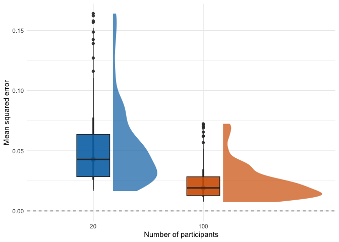

```r
(boxplot_mse_n = overall_df %>%
  ggplot(aes(x = as.factor(N), y = B1_se, fill = as.factor(N), group = as.factor(N))) +
  stat_halfeye(justification = -0.2, alpha = 0.7, outlier.size = 1) +
  geom_boxplot(width = 0.3, alpha = 0.9) +
  theme_minimal() +
  scale_fill_manual(values = cbPalette_other) +
  ylab("Mean squared error") +
  xlab("Number of participants") +
  theme(legend.position = "none") +
  geom_hline(yintercept = 0, linetype = "dashed")
  )
```

#### Time-series length

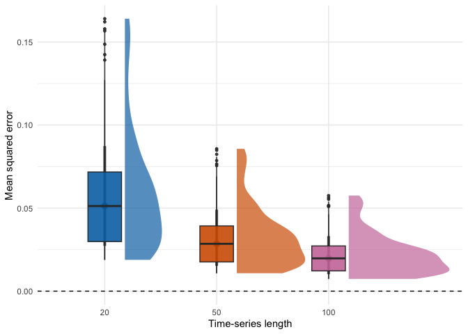

```r
(boxplot_mse_t = overall_df %>%
  ggplot(aes(x = as.factor(T.obs), y = B1_se, fill = as.factor(T.obs), group = as.factor(T.obs))) +
  stat_halfeye(justification = -0.2, alpha = 0.7) +
  geom_boxplot(width = 0.3, alpha = 0.9, outlier.size = 1) +
  theme_minimal() +
  scale_fill_manual(values = cbPalette_other) +
  ylab("Mean squared error") +
  xlab("Time-series length") +
  theme(legend.position = "none") +
  geom_hline(yintercept = 0, linetype = "dashed")
  )
```

#### Compliance

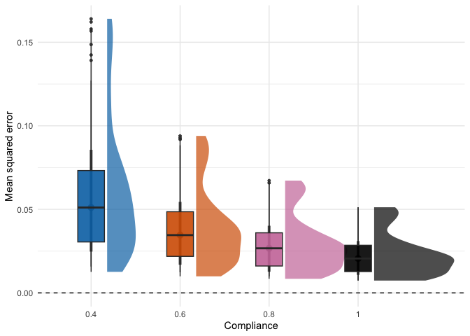

```r
(boxplot_mse_compliance = overall_df %>%
  ggplot(aes(x = as.factor(comp_mean), y = B1_se, fill = as.factor(comp_mean), group = as.factor(comp_mean))) +
  stat_halfeye(justification = -0.2, alpha = 0.7) +
  geom_boxplot(width = 0.3, alpha = 0.9, outlier.size = 1) +
  theme_minimal() +
  scale_fill_manual(values = cbPalette_other) +
  ylab("Mean squared error") +
  xlab("Compliance") +
  theme(legend.position = "none") +
  geom_hline(yintercept = 0, linetype = "dashed")
  )
```

#### Interaction: Time-series length and compliance

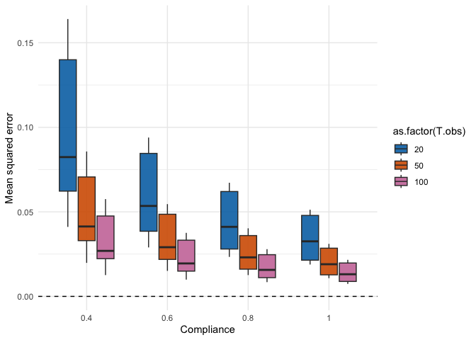

```r
(boxplot_mse_compliance_t = overall_df %>%
  ggplot(aes(x = as.factor(comp_mean), y = B1_se, fill = as.factor(T.obs))) +
  geom_boxplot(width = 0.7, alpha = 0.9, outlier.size = 1) +
  theme_minimal() +
  scale_fill_manual(values = cbPalette_other) +
  ylab("Mean squared error") +
  xlab("Compliance") +
  geom_hline(yintercept = 0, linetype = "dashed"))
```

#### Interaction: Number of participants and compliance

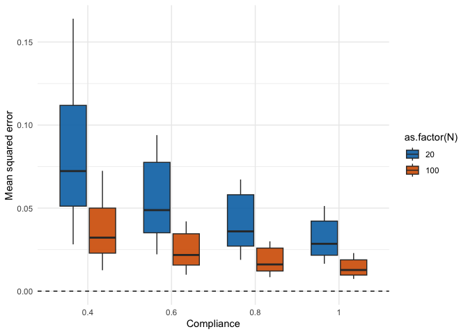

```r
(boxplot_mse_compliance_n = overall_df %>%
  ggplot(aes(x = as.factor(comp_mean), y = B1_se, fill = as.factor(N))) +
  geom_boxplot(width = 0.7, alpha = 0.9, outlier.size = 1) +
  theme_minimal() +
  scale_fill_manual(values = cbPalette_other) +
  ylab("Mean squared error") +
  xlab("Compliance") +
  geom_hline(yintercept = 0, linetype = "dashed"))
```

## Outcome: Statistical power

### Power ANOVA

```r
anova_power = aov(formula = B1_pow ~ N * T.obs * miss_type * comp_mean * B1_sim,
                 data = overall_df)

(anova_power_results = summary(anova_power))
```

```
##                                     Df Sum Sq Mean Sq F value   Pr(>F)
## N                                    1  0.418   0.418  21.623 5.67e-06 ***
## T.obs                                1  1.211   1.211  62.704 1.11e-13 ***
## miss_type                            3  3.365   1.122  58.062  < 2e-16 ***
## comp_mean                            1  4.465   4.465 231.147  < 2e-16 ***
## B1_sim                               1  1.352   1.352  70.010 6.36e-15 ***
## N:T.obs                              1  0.078   0.078   4.043 0.045567 *
## N:miss_type                          3  0.103   0.034   1.770 0.153691
## T.obs:miss_type                      3  0.338   0.113   5.839 0.000740 ***
## N:comp_mean                          1  0.225   0.225  11.632 0.000769 ***
## T.obs:comp_mean                      1  0.795   0.795  41.148 8.28e-10 ***
## miss_type:comp_mean                  3  3.124   1.041  53.910  < 2e-16 ***
## N:B1_sim                             1  0.087   0.087   4.519 0.034614 *
## T.obs:B1_sim                         1  0.236   0.236  12.238 0.000565 ***
## miss_type:B1_sim                     3  0.444   0.148   7.655 6.81e-05 ***
## comp_mean:B1_sim                     1  0.763   0.763  39.486 1.70e-09 ***
## N:T.obs:miss_type                    3  0.013   0.004   0.229 0.875944
## N:T.obs:comp_mean                    1  0.011   0.011   0.567 0.452245
## N:miss_type:comp_mean                3  0.028   0.009   0.478 0.698183
## T.obs:miss_type:comp_mean            3  0.226   0.075   3.899 0.009630 **
## N:T.obs:B1_sim                       1  0.017   0.017   0.890 0.346571
## N:miss_type:B1_sim                   3  0.014   0.005   0.247 0.863622
## T.obs:miss_type:B1_sim               3  0.076   0.025   1.307 0.272787
## N:comp_mean:B1_sim                   1  0.005   0.005   0.248 0.619064
## T.obs:comp_mean:B1_sim               1  0.022   0.022   1.128 0.289260
## miss_type:comp_mean:B1_sim           3  0.135   0.045   2.329 0.075351 .
## N:T.obs:miss_type:comp_mean          3  0.056   0.019   0.963 0.410843
## N:T.obs:miss_type:B1_sim             3  0.033   0.011   0.566 0.638218
## N:T.obs:comp_mean:B1_sim             1  0.000   0.000   0.019 0.890883
## N:miss_type:comp_mean:B1_sim         3  0.066   0.022   1.134 0.336078
## T.obs:miss_type:comp_mean:B1_sim     3  0.272   0.091   4.691 0.003379 **
## N:T.obs:miss_type:comp_mean:B1_sim   3  0.086   0.029   1.487 0.218794
## Residuals                          224  4.327   0.019
## ---
## Signif. codes:  0 '***' 0.001 '**' 0.01 '*' 0.05 '.' 0.1 ' ' 1
```

### Power ANOVA effect sizes

```r
omega_squared(anova_power, partial = TRUE)
```

| Parameter | Omega2_partial | CI | CI_low | CI_high |
| --- | --- | --- | --- | --- |
| N | 0.0668226 | 0.95 | 0.0235957 | 1 |
| T.obs | 0.1764461 | 0.95 | 0.1073313 | 1 |
| miss_type | 0.3728047 | 0.95 | 0.2896608 | 1 |
| comp_mean | 0.4441730 | 0.95 | 0.3680202 | 1 |
| B1_sim | 0.1932995 | 0.95 | 0.1219654 | 1 |
| N:T.obs | 0.0104538 | 0.95 | 0.0000000 | 1 |
| N:miss_type | 0.0079595 | 0.95 | 0.0000000 | 1 |
| T.obs:miss_type | 0.0479909 | 0.95 | 0.0063182 | 1 |
| N:comp_mean | 0.0356025 | 0.95 | 0.0065180 | 1 |
| T.obs:comp_mean | 0.1223474 | 0.95 | 0.0630020 | 1 |
| miss_type:comp_mean | 0.3553134 | 0.95 | 0.2717020 | 1 |
| N:B1_sim | 0.0120714 | 0.95 | 0.0000000 | 1 |
| T.obs:B1_sim | 0.0375556 | 0.95 | 0.0074001 | 1 |
| miss_type:B1_sim | 0.0648312 | 0.95 | 0.0157780 | 1 |
| comp_mean:B1_sim | 0.1178781 | 0.95 | 0.0595570 | 1 |
| N:T.obs:miss_type | 0.0000000 | 0.95 | 0.0000000 | 1 |
| N:T.obs:comp_mean | 0.0000000 | 0.95 | 0.0000000 | 1 |
| N:miss_type:comp_mean | 0.0000000 | 0.95 | 0.0000000 | 1 |
| T.obs:miss_type:comp_mean | 0.0293104 | 0.95 | 0.0000000 | 1 |
| N:T.obs:B1_sim | 0.0000000 | 0.95 | 0.0000000 | 1 |
| N:miss_type:B1_sim | 0.0000000 | 0.95 | 0.0000000 | 1 |
| T.obs:miss_type:B1_sim | 0.0031927 | 0.95 | 0.0000000 | 1 |
| N:comp_mean:B1_sim | 0.0000000 | 0.95 | 0.0000000 | 1 |
| T.obs:comp_mean:B1_sim | 0.0004456 | 0.95 | 0.0000000 | 1 |
| miss_type:comp_mean:B1_sim | 0.0136497 | 0.95 | 0.0000000 | 1 |
| N:T.obs:miss_type:comp_mean | 0.0000000 | 0.95 | 0.0000000 | 1 |
| N:T.obs:miss_type:B1_sim | 0.0000000 | 0.95 | 0.0000000 | 1 |
| N:T.obs:comp_mean:B1_sim | 0.0000000 | 0.95 | 0.0000000 | 1 |
| N:miss_type:comp_mean:B1_sim | 0.0013952 | 0.95 | 0.0000000 | 1 |
| T.obs:miss_type:comp_mean:B1_sim | 0.0370196 | 0.95 | 0.0011682 | 1 |
| N:T.obs:miss_type:comp_mean:B1_sim | 0.0050512 | 0.95 | 0.0000000 | 1 |

**Interactions:**

### Power: mean comparisons

#### Compliance

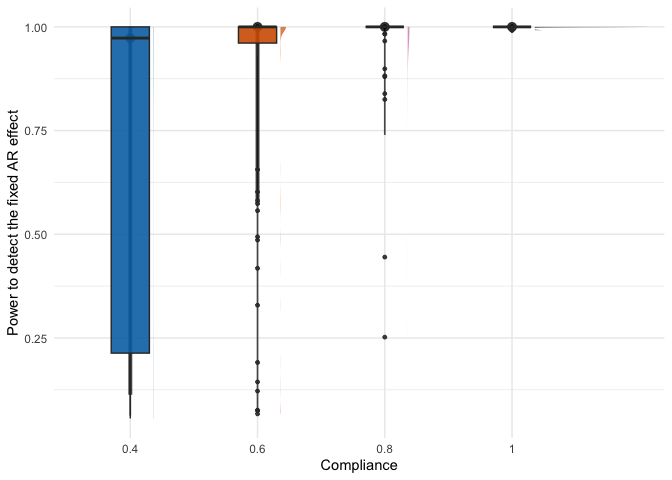

```r
(boxplot_power_compliance = overall_df %>%
  ggplot(aes(x = as.factor(comp_mean), y = B1_pow, fill = as.factor(comp_mean), group = as.factor(comp_mean))) +
  stat_halfeye(justification = -0.2, alpha = 0.7) +
  geom_boxplot(width = 0.3, alpha = 0.9, outlier.size = 1) +
  theme_minimal() +
  scale_fill_manual(values = cbPalette_other) +
  ylab("Power to detect the fixed AR effect") +
  xlab("Compliance") +
  theme(legend.position = "none")
  )
```

#### Missingness type

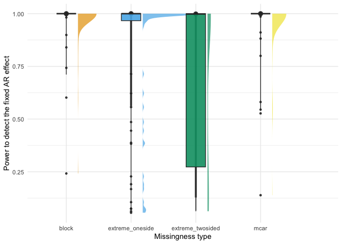

```r
(boxplot_power_miss_type = overall_df %>%
  ggplot(aes(x = as.factor(miss_type), y = B1_pow, fill = as.factor(miss_type), group = as.factor(miss_type))) +
  stat_halfeye(justification = -0.2, alpha = 0.7) +
  geom_boxplot(width = 0.3, alpha = 0.9, outlier.size = 1) +
  theme_minimal() +
  scale_fill_manual(values = cbPalette) +
  ylab("Power to detect the fixed AR effect") +
  xlab("Missingness type") +
  theme(legend.position = "none")
  )
```

#### Simulated fixed AR effect

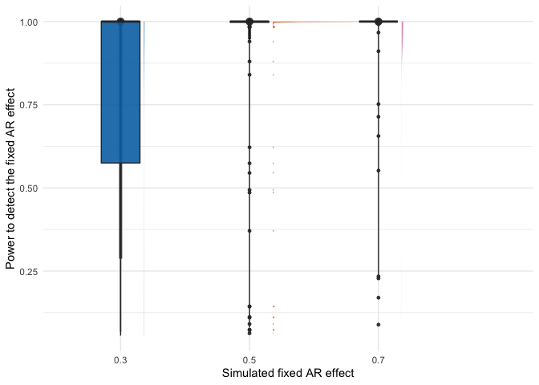

```r
(boxplot_power_ar = overall_df %>%
  ggplot(aes(x = as.factor(B1_sim), y = B1_pow, fill = as.factor(B1_sim), group = as.factor(B1_sim))) +
  stat_halfeye(justification = -0.2, alpha = 0.7) +
  geom_boxplot(width = 0.3, alpha = 0.9, outlier.size = 1) +
  theme_minimal() +
  scale_fill_manual(values = cbPalette_other) +
  ylab("Power to detect the fixed AR effect") +
  xlab("Simulated fixed AR effect") +
  theme(legend.position = "none")
  )
```

#### Number of timepoints

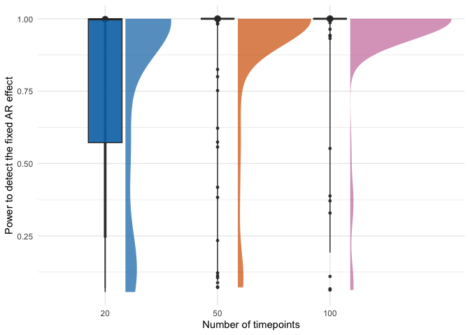

```r
(boxplot_power_t = overall_df %>%
  ggplot(aes(x = as.factor(T.obs), y = B1_pow, fill = as.factor(T.obs), group = as.factor(T.obs))) +
  stat_halfeye(justification = -0.2, alpha = 0.7) +
  geom_boxplot(width = 0.3, alpha = 0.9, outlier.size = 1) +
  theme_minimal() +
  scale_fill_manual(values = cbPalette_other) +
  ylab("Power to detect the fixed AR effect") +
  xlab("Number of timepoints") +
  theme(legend.position = "none")
  )
```

#### Interaction: Missingness type and compliance

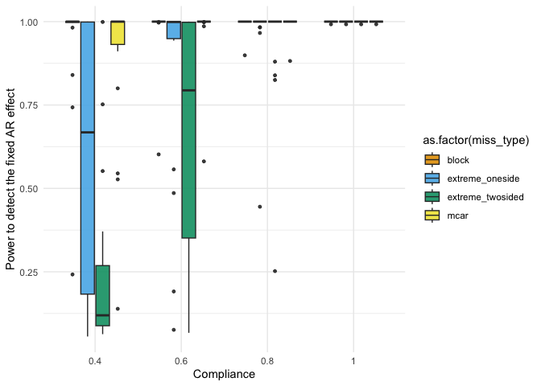

```r
(boxplot_power_compliance_miss_type = overall_df %>%
  ggplot(aes(x = as.factor(comp_mean), y = B1_pow, fill = as.factor(miss_type))) +
  geom_boxplot(width = 0.7, alpha = 0.9, outlier.size = 1) +
  theme_minimal() +
  scale_fill_manual(values = cbPalette) +
  ylab("Power to detect the fixed AR effect") +
  xlab("Compliance") )
```

Interestingly, the effect of compliance and missingness type is much larger than the effect of the number of timepoints / participants.

## Outcome: Bias in person-mean estimation

### Bias in AR effect estimation and bias in person-mean estimation

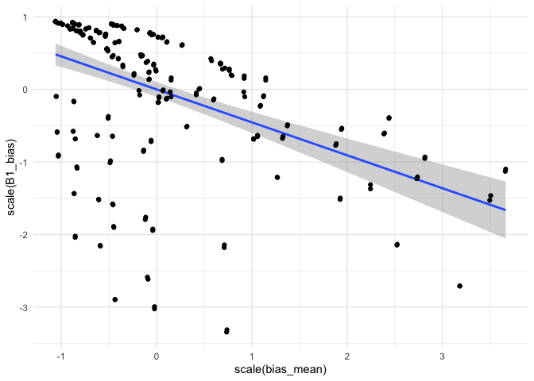

```r
overall_df %>%
  ggplot(aes(x = scale(bias_mean), y = scale(B1_bias))) +
  geom_smooth(method = 'lm') +
  geom_point() + theme_minimal()
```

```r
summary(lm(B1_bias~bias_mean, data = overall_df))
```

```
##
## Call:
## lm(formula = B1_bias ~ bias_mean, data = overall_df)
##
## Residuals:
##      Min       1Q   Median       3Q      Max
## -0.46807 -0.02324  0.06004  0.07862  0.11341
##
## Coefficients:
##             Estimate Std. Error t value Pr(>|t|)
## (Intercept) -0.05049    0.01441  -3.503 0.000534 ***
## bias_mean   -0.15643    0.01815  -8.620 4.64e-16 ***
## ---
## Signif. codes:  0 '***' 0.001 '**' 0.01 '*' 0.05 '.' 0.1 ' ' 1
##
## Residual standard error: 0.1349 on 286 degrees of freedom
## Multiple R-squared:  0.2062, Adjusted R-squared:  0.2035
## F-statistic: 74.31 on 1 and 286 DF,  p-value: 4.641e-16
```

### Person-mean bias ANOVA

```r
anova_personmean = aov(formula = bias_mean ~ N * T.obs * miss_type * comp_mean * B1_sim,
                 data = overall_df)

(anova_personmean_results = summary(anova_personmean))
```

```
##                                     Df Sum Sq Mean Sq  F value   Pr(>F)
## N                                    1  0.000   0.000    0.004  0.94677
## T.obs                                1  4.043   4.043  642.274  < 2e-16 ***
## miss_type                            3 19.635   6.545 1039.732  < 2e-16 ***
## comp_mean                            1  7.777   7.777 1235.375  < 2e-16 ***
## B1_sim                               1  7.167   7.167 1138.546  < 2e-16 ***
## N:T.obs                              1  0.000   0.000    0.001  0.96931
## N:miss_type                          3  0.000   0.000    0.001  0.99997
## T.obs:miss_type                      3  0.739   0.246   39.150  < 2e-16 ***
## N:comp_mean                          1  0.000   0.000    0.000  0.98286
## T.obs:comp_mean                      1  0.046   0.046    7.261  0.00758 **
## miss_type:comp_mean                  3 13.680   4.560  724.400  < 2e-16 ***
## N:B1_sim                             1  0.000   0.000    0.000  0.98995
## T.obs:B1_sim                         1  0.314   0.314   49.949 1.98e-11 ***
## miss_type:B1_sim                     3  0.011   0.004    0.561  0.64122
## comp_mean:B1_sim                     1  0.010   0.010    1.535  0.21666
## N:T.obs:miss_type                    3  0.000   0.000    0.001  0.99997
## N:T.obs:comp_mean                    1  0.000   0.000    0.000  0.98391
## N:miss_type:comp_mean                3  0.000   0.000    0.001  0.99995
## T.obs:miss_type:comp_mean            3  0.350   0.117   18.523 9.04e-11 ***
## N:T.obs:B1_sim                       1  0.000   0.000    0.000  0.99431
## N:miss_type:B1_sim                   3  0.000   0.000    0.000  1.00000
## T.obs:miss_type:B1_sim               3  0.032   0.011    1.687  0.17062
## N:comp_mean:B1_sim                   1  0.000   0.000    0.000  0.99620
## T.obs:comp_mean:B1_sim               1  0.022   0.022    3.432  0.06527 .
## miss_type:comp_mean:B1_sim           3  0.017   0.006    0.892  0.44584
## N:T.obs:miss_type:comp_mean          3  0.000   0.000    0.000  1.00000
## N:T.obs:miss_type:B1_sim             3  0.000   0.000    0.000  0.99999
## N:T.obs:comp_mean:B1_sim             1  0.000   0.000    0.000  0.99971
## N:miss_type:comp_mean:B1_sim         3  0.000   0.000    0.000  1.00000
## T.obs:miss_type:comp_mean:B1_sim     3  0.027   0.009    1.427  0.23572
## N:T.obs:miss_type:comp_mean:B1_sim   3  0.000   0.000    0.000  1.00000
## Residuals                          224  1.410   0.006
## ---
## Signif. codes:  0 '***' 0.001 '**' 0.01 '*' 0.05 '.' 0.1 ' ' 1
```

### Person-mean bias ANOVA effect sizes

```r
omega_squared(anova_personmean, partial = TRUE)
```

| Parameter | Omega2_partial | CI | CI_low | CI_high |
| --- | --- | --- | --- | --- |
| N | 0.0000000 | 0.95 | 0.0000000 | 1 |
| T.obs | 0.6900808 | 0.95 | 0.6393006 | 1 |
| miss_type | 0.9153985 | 0.95 | 0.9004727 | 1 |
| comp_mean | 0.8108219 | 0.95 | 0.7783806 | 1 |
| B1_sim | 0.7979721 | 0.95 | 0.7634588 | 1 |
| N:T.obs | 0.0000000 | 0.95 | 0.0000000 | 1 |
| N:miss_type | 0.0000000 | 0.95 | 0.0000000 | 1 |
| T.obs:miss_type | 0.2843858 | 0.95 | 0.2008716 | 1 |
| N:comp_mean | 0.0000000 | 0.95 | 0.0000000 | 1 |
| T.obs:comp_mean | 0.0212759 | 0.95 | 0.0011887 | 1 |
| miss_type:comp_mean | 0.8828411 | 0.95 | 0.8622364 | 1 |
| N:B1_sim | 0.0000000 | 0.95 | 0.0000000 | 1 |
| T.obs:B1_sim | 0.1452704 | 0.95 | 0.0812358 | 1 |
| miss_type:B1_sim | 0.0000000 | 0.95 | 0.0000000 | 1 |
| comp_mean:B1_sim | 0.0018542 | 0.95 | 0.0000000 | 1 |
| N:T.obs:miss_type | 0.0000000 | 0.95 | 0.0000000 | 1 |
| N:T.obs:comp_mean | 0.0000000 | 0.95 | 0.0000000 | 1 |
| N:miss_type:comp_mean | 0.0000000 | 0.95 | 0.0000000 | 1 |
| T.obs:miss_type:comp_mean | 0.1543557 | 0.95 | 0.0822283 | 1 |
| N:T.obs:B1_sim | 0.0000000 | 0.95 | 0.0000000 | 1 |
| N:miss_type:B1_sim | 0.0000000 | 0.95 | 0.0000000 | 1 |
| T.obs:miss_type:B1_sim | 0.0071067 | 0.95 | 0.0000000 | 1 |
| N:comp_mean:B1_sim | 0.0000000 | 0.95 | 0.0000000 | 1 |
| T.obs:comp_mean:B1_sim | 0.0083725 | 0.95 | 0.0000000 | 1 |
| miss_type:comp_mean:B1_sim | 0.0000000 | 0.95 | 0.0000000 | 1 |
| N:T.obs:miss_type:comp_mean | 0.0000000 | 0.95 | 0.0000000 | 1 |
| N:T.obs:miss_type:B1_sim | 0.0000000 | 0.95 | 0.0000000 | 1 |
| N:T.obs:comp_mean:B1_sim | 0.0000000 | 0.95 | 0.0000000 | 1 |
| N:miss_type:comp_mean:B1_sim | 0.0000000 | 0.95 | 0.0000000 | 1 |
| T.obs:miss_type:comp_mean:B1_sim | 0.0044273 | 0.95 | 0.0000000 | 1 |
| N:T.obs:miss_type:comp_mean:B1_sim | 0.0000000 | 0.95 | 0.0000000 | 1 |

**Interactions**:

### Person-mean bias: mean comparisons

#### Missingness type

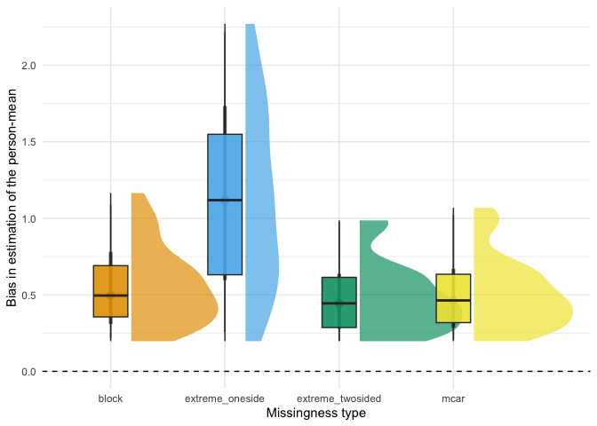

```r
(boxplot_personmean_type = overall_df %>%
  ggplot(aes(x = as.factor(miss_type), y = bias_mean, fill = as.factor(miss_type), group = as.factor(miss_type))) +
  stat_halfeye(justification = -0.2, alpha = 0.7, outlier.size = 1) +
  geom_boxplot(width = 0.3, alpha = 0.9) +
  theme_minimal() +
  scale_fill_manual(values = cbPalette) +
  ylab("Bias in estimation of the person-mean") +
  xlab("Missingness type") +
  theme(legend.position = "none") +
  geom_hline(yintercept = 0, linetype = "dashed")
  )
```

#### Mean compliance

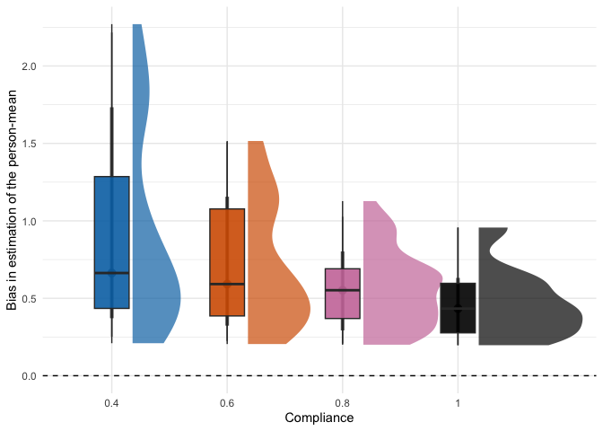

```r
(boxplot_personmean_compliance = overall_df %>%
  ggplot(aes(x = as.factor(comp_mean), y = bias_mean, fill = as.factor(comp_mean), group = as.factor(comp_mean))) +
  stat_halfeye(justification = -0.2, alpha = 0.7, outlier.size = 1) +
  geom_boxplot(width = 0.3, alpha = 0.9) +
  theme_minimal() +
  scale_fill_manual(values = cbPalette_other) +
  ylab("Bias in estimation of the person-mean") +
  xlab("Compliance") +
  theme(legend.position = "none") +
  geom_hline(yintercept = 0, linetype = "dashed")
  )
```

#### Real fixed AR effect

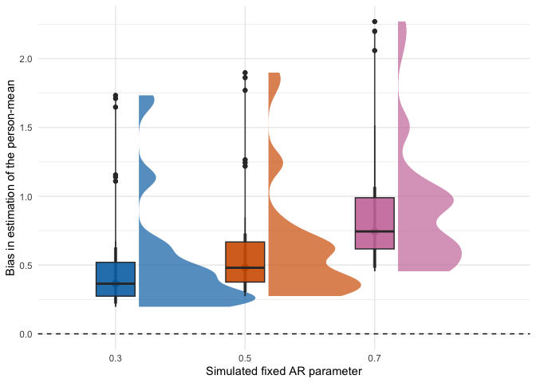

```r
(boxplot_personmean_ar = overall_df %>%
  ggplot(aes(x = as.factor(B1_sim), y = bias_mean, fill = as.factor(B1_sim), group = as.factor(B1_sim))) +
  stat_halfeye(justification = -0.2, alpha = 0.7, outlier.size = 1) +
  geom_boxplot(width = 0.3, alpha = 0.9) +
  theme_minimal() +
  scale_fill_manual(values = cbPalette_other) +
  ylab("Bias in estimation of the person-mean") +
  xlab("Simulated fixed AR parameter") +
  theme(legend.position = "none") +
  geom_hline(yintercept = 0, linetype = "dashed")
  )
```

#### Time-series length

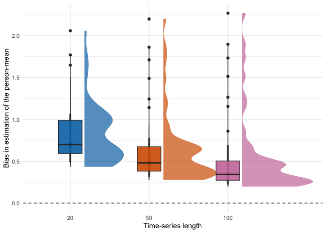

```r
(boxplot_personmean_t = overall_df %>%
  ggplot(aes(x = as.factor(T.obs), y = bias_mean, fill = as.factor(T.obs), group = as.factor(T.obs))) +
  stat_halfeye(justification = -0.2, alpha = 0.7, outlier.size = 1) +
  geom_boxplot(width = 0.3, alpha = 0.9) +
  theme_minimal() +
  scale_fill_manual(values = cbPalette_other) +
  ylab("Bias in estimation of the person-mean") +
  xlab("Time-series length") +
  theme(legend.position = "none") +
  geom_hline(yintercept = 0, linetype = "dashed")
  )
```

#### Interaction: Missingness type * Compliance

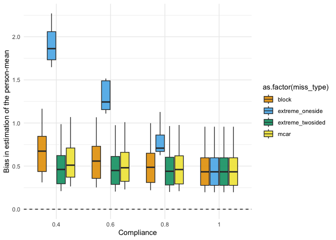

```r
(boxplot_personmean_compliance_misstype = overall_df %>%
  ggplot(aes(x = as.factor(comp_mean), y = bias_mean, fill = as.factor(miss_type))) +
  geom_boxplot(width = 0.7, alpha = 0.9, outlier.size = 1) +
  theme_minimal() +
  scale_fill_manual(values = cbPalette) +
  ylab("Bias in estimation of the person-mean") +
  xlab("Compliance") +
  geom_hline(yintercept = 0, linetype = "dashed")
  )
```

#### Interaction: Missingness type and time-series length

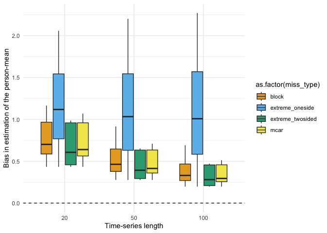

```r
(boxplot_personmean_compliance_misstype = overall_df %>%
  ggplot(aes(x = as.factor(T.obs), y = bias_mean, fill = as.factor(miss_type))) +
  geom_boxplot(width = 0.7, alpha = 0.9, outlier.size = 1) +
  theme_minimal() +
  scale_fill_manual(values = cbPalette) +
  ylab("Bias in estimation of the person-mean") +
  xlab("Time-series length") +
  geom_hline(yintercept = 0, linetype = "dashed")
  )
```